# AZCRO Microbiome Project (VA08_a7_180819.1)

Daniel Sprockett

August 19, 2018

# Figure 1 - Study Design and Clinical Outcomes

### Manuscript Title: (*tentative*)

## Antibiotic-Specific Microbiome Response Associated with Disease Remission in a Pediatric Crohn’s Disease Cohort

### Authors:

Daniel Sprockett<sup>1*</sup>, Natalie Fischer<sup>2*</sup>, Rotem Sigall Boneh<sup>3</sup>, Michal Kori<sup>5</sup>, Jarek Kierkus<sup>6</sup>, Malgorzata Sladek<sup>7</sup>, Johanna Escher<sup>8</sup>, Eytan Wine<sup>9</sup>, Baruch Yerushalmi<sup>10</sup>, Jorge Amil Dias<sup>11</sup>, Ron Shaoul<sup>12</sup>, Dan Turner<sup>14</sup>, Athos Bousvaros<sup>13</sup>, Arie Levine<sup>3,4</sup>, and David Relman<sup>1,2,15†</sup>

1. Department of Microbiology & Immunology, Stanford University School of Medicine, Stanford, CA 94305, USA
2. Department of Medicine, Stanford University School of Medicine, Stanford, CA 94305, USA
3. Pediatric Gastroenterology and Nutrition Unit, Wolfson Medical Center, Holon, Israel,
4. Tel Aviv University, Tel Aviv, Israel,
5. Kaplan Medical Center, Pediatric Day Care Unit, Rehovot, Israel,
6. The Children’s Memorial Health Institute, Gastroenterology, Hepatology, Feeding Disorders and Pediatrics, Warsaw, Poland,
7. Jagiellonian University Medical College, Department of Pediatrics, Gastroenterology and Nutrition, Cracow, Poland,
8. Erasmus MC-Sophia Children’s Hospital, Department of Pediatric Gastroenterology, Rotterdam, the Netherlands,
9. University of Alberta, Division of Pediatric Gastroenterology, Department of Pediatrics, Edmonton, Canada,
10. Pediatric Gastroenterology Unit, Soroka University Medical Center and Faculty of Health Sciences, Ben-Gurion University of the Negev, Israel ,
11. Hospital, S. Joao, Department of Pediatrics, Porto, Portugal,
12. Ruth Children’s Hospital, Pediatric Gastroenterology Unit, Rambam Medical Center,
13. Boston Children’s Hospital Division of Gastroenterology and Nutrition, , Harvard Medical School, Boston, MA,
14. The Juliet Keidan Institute of Pediatric Gastroenterology & Nutrition, Shaare Zedek Medical Center , The Hebrew University of Jerusalem, Jerusalem, Israel
15. Veterans Affairs Palo Alto Health Care System, Palo Alto, CA 94304, USA

* These authors contributed equally to this project.

† Corresponding Author.

# Key Citations

Follow up to [Levine *et al.* (2018)](http://gut.bmj.com/content/early/2018/02/02/gutjnl-2017-315199)

# Innovation:

This investagations improves on previous knowledge by using a relatively large patient Crohn’s Disease cohort with well-defined inclusion criteria and a longitudinal sampling design. Previous studies have used popluations with mixed UC/CD diagnoses and a wide range of treatments.

# Goals:

The main goal of this study is to invesitgate potential synergistic effects of dual antibiotic therapy on pediatric Crohn’s Disease patients, as well as to identify microbial biomarkers that can predict the liklihood of remission in both treatment settings.

# Initialize R

Set the SavePath for figures.

```r
#R.Version()
require("ggplot2"); #packageVersion("ggplot2")
require("phyloseq"); #packageVersion("phyloseq")
require("gridExtra"); #packageVersion("gridExtra")
require("reshape2"); #packageVersion("reshape2")
require("tidyverse"); #packageVersion("tidyverse")
require("reltools"); #packageVersion("reltools")
library("Biostrings"); #packageVersion("Biostrings")

theme_set(theme_bw(base_size = 11))

set.seed(8675309)

setwd("/Users/daniel/Documents/Relman_Lab/projects/VA08_AZCRO/VA08_a7_180819/")
SavePath <- paste0(getwd(),"/VA08_a7_180819.1_Figures/")
dir.create(file.path(SavePath), showWarnings = FALSE)
```

### Import Data

Import Microbiome and Subject Data.

```r
AZCRO_ps <-readRDS("/Users/daniel/Documents/Relman_Lab/projects/VA08_AZCRO/VA08_a7_180819/VA08_AZCRO_v3_ps.rds")

AZCRO_Subject_df <- read.table("/Users/daniel/Documents/Relman_Lab/projects/VA08_AZCRO/VA08_a7_180819/VA08_AZCRO_Subject_Data.txt", header = TRUE, sep = "\t")

AZCRO_Subject_df$Treatment_Group <- factor(AZCRO_Subject_df$Treatment_Group, levels = c("MET", "MET+AZ", "MET/MET+AZ"))
```

Create standard feature palettes for consisent plots.

```r
ps <- AZCRO_ps

Group_pal <- c("red1", "blue1", "purple1")
names(Group_pal) <- levels(ps@sam_data$Treatment_Group)

Week_pal <- rainbow(length(levels(ps@sam_data$Week)), s = .85, v=0.75, start = .15)
names(Week_pal) <- levels(ps@sam_data$Week)

AZCRO_ps@sam_data$Group_By_Week <- paste0(AZCRO_ps@sam_data$Treatment_Group, "_", AZCRO_ps@sam_data$Week)
AZCRO_ps@sam_data$Group_By_Week <- factor(AZCRO_ps@sam_data$Group_By_Week,
      levels = c(
        "MET_Week0", "MET_Week4", "MET_Week8", "MET_Week12",
        "MET+AZ_Week0", "MET+AZ_Week4", "MET+AZ_Week8", "MET+AZ_Week12",
        "MET/MET+AZ_Week0", "MET/MET+AZ_Week4", "MET/MET+AZ_Week8", "MET/MET+AZ_Week12"))

Group_By_Week_pal <- c(rep("red3", 4), rep("blue3", 4), "red3", "red3", "purple3", "purple3")
names(Group_By_Week_pal) <- levels(AZCRO_ps@sam_data$Group_By_Week)

Antibiotics_pal <- c(.5, 1, .5)
names(Antibiotics_pal) <- levels(ps@sam_data$Antibiotics)

Site_pal <- rainbow(length(levels(ps@sam_data$Site_ID)), s = .5, v=0.85, start = .2)
names(Site_pal) <- levels(ps@sam_data$Site_ID)
```

# Analysis Summary

**Figure List:**

- Figure 1: Clinical Outcomes Following Treatment
  - 1A. Fig 1A. Study Design
  - 1B. Primary Clinical Outcome: PCDAI
  - S1A. Secondary Clinical Outcome: CRP
  - S1B. Secondary Clinical Outcome: ESR
  - S1C. Secondary Clinical Outcome: Calprotectin

# Figure 1

## Figure 1A. Study Design

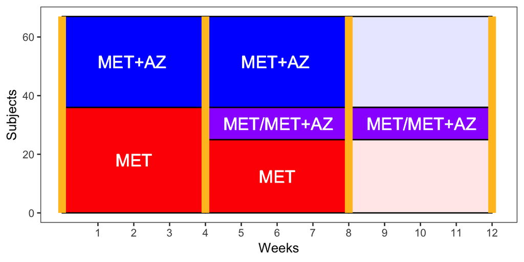

```r
ps0 <- AZCRO_ps
ps <- merge_samples(ps0, "Subject_ID")
df <- data.frame("Subject_ID" = ps0@sam_data$Subject_ID,
                 "Treatment_Group" = ps0@sam_data$Treatment_Group)
ps@sam_data$Treatment_Group <- df$Treatment_Group[match(sample_names(ps), df$Subject_ID)]
ps@sam_data$Treatment_Group <- factor(ps@sam_data$Treatment_Group ,
                                      levels = c("MET", "MET/MET+AZ", "MET+AZ"))

tb <- data.frame(table(ps@sam_data$Treatment_Group))
colnames(tb) <-c("Treatment_Group", "Subjects")
tb <- rbind(tb, tb, tb)
tb$Weeks <- rep(c("Weeks0-4", "Weeks4-8", "Weeks8-12"), each = 3)
tb$xmin <- rep(c(0, 4, 8), each = 3)
tb$xmax <- rep(c(4, 8, 12), each = 3)
# combine MET and MET/MET+AZ from Weeks0-4
tb$Subjects[tb$Treatment_Group == "MET" & tb$Weeks == "Weeks0-4"] <- tb$Subjects[tb$Treatment_Group == "MET" & tb$Weeks == "Weeks0-4"] + tb$Subjects[tb$Treatment_Group == "MET/MET+AZ" & tb$Weeks == "Weeks0-4"]
tb <- tb[!c(tb$Treatment_Group == "MET/MET+AZ" & tb$Weeks == "Weeks0-4"),]
tb$ymin <- c(0, 36,
             0, 25, 25+11,
             0, 25, 25+11)
tb$ymax <- c(36, 36+31,
             25, 25+11, 25+11+31,
             25, 25+11, 25+11+31)
tb$alpha <- c(rep(1, 5), .3, 1, .3)


p <- ggplot(tb)
p <- p + geom_rect(aes(xmin = xmin, xmax = xmax, ymin = ymin, ymax = ymax, alpha = alpha, fill = Treatment_Group), color = "black")
p <- p + scale_fill_manual(values = Group_pal)
#p <- p + scale_y_reverse()
p <- p + xlab("Weeks")
p <- p + ylab("Subjects")
p <- p + scale_x_continuous(name = "Weeks", breaks = seq(0:12), labels = seq(0:12), limits = c(0, 12.1))
p <- p + geom_text(aes(x = 1.5, y = (tb$ymax[1] - tb$ymin[1])/2), label = "MET", colour = "white", size = 5, hjust=0)
p <- p + geom_text(aes(x = 1, y = tb$ymax[1] + (tb$ymax[2] - tb$ymin[2])/2), label = "MET+AZ", colour = "white", size = 5, hjust=0)

p <- p + geom_text(aes(x = 5.5, y = (tb$ymax[3] - tb$ymin[3])/2), label = "MET", colour = "white", size = 5, hjust=0)
p <- p + geom_text(aes(x = 4.5, y = tb$ymax[3] + (tb$ymax[4] - tb$ymin[4])/2), label = "MET/MET+AZ", colour = "white", size = 5, hjust=0)
p <- p + geom_text(aes(x = 5, y = tb$ymax[4] + (tb$ymax[5] - tb$ymin[5])/2), label = "MET+AZ", colour = "white", size = 5, hjust=0)

p <- p + geom_text(aes(x = 8.5, y = tb$ymax[6] + (tb$ymax[7] - tb$ymin[7])/2), label = "MET/MET+AZ", colour = "white", size = 5, hjust=0)

p <- p + annotate("segment", x = seq(0,12,by=4), xend = seq(0,12,by=4), y = rep(0,4), yend = rep(max(tb$ymax),4), colour = "goldenrod1", size = 3)

p <- p + theme(legend.position="none")
p <- p + theme(
  panel.background = element_rect(fill = "transparent",colour = NA),
  plot.background = element_rect(fill = "transparent",colour = NA),
  legend.background = element_rect(fill = "transparent",colour = NA),
  panel.grid.major = element_blank(),
  panel.grid.minor = element_blank(),
  legend.key = element_rect(fill = "transparent",colour = NA))
p
```

```r
pdf(paste0(SavePath, "plot_AZCRO_SamplingDesign.pdf"), width=6,height=3)
  print(p)
invisible(dev.off())
```

## Figure 1B. PCDAI

PCDAI - Pediatric Crohn’s Disease Activity Index

Plot how each individual’s response to treatment changes over time. Facet plots by treatment group and treatment outcome at week 4.

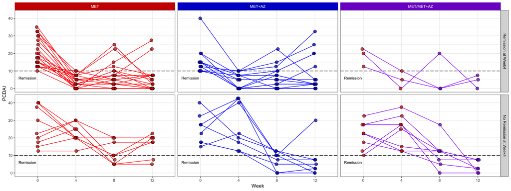

```r
df <- AZCRO_Subject_df
df <- data.frame(Subject_ID = df$Subject_ID, Treatment_Group = df$Treatment_Group, Week0 = df$PCDAI_Week0, Week4 = df$PCDAI_Week4, Week8 = df$PCDAI_Week8, Week12 = df$PCDAI_Week12)
#df$Response <- ifelse(df$Week0 - df$Week4 >= 12.5 | df$Week4 <= 10, "Response", "No Response")
df$Remission_Week4 <- ifelse(df$Week4 <= 10, "Remission", "No Remission")
df$Remission_Week8 <- ifelse(df$Week8 <= 10, "Remission", "No Remission")
df$Remission_Week12 <- ifelse(df$Week12 <= 10, "Remission", "No Remission")

mdf <- melt(df)
colnames(mdf) <- c("Subject_ID", "Treatment_Group", "Remission_Week4", "Remission_Week8", "Remission_Week12", "Week", "PCDAI")

mdf$Group_By_Week <- paste0(mdf$Treatment_Group, "_", mdf$Week)

mdf$Group_By_Week <- factor(mdf$Group_By_Week,
      levels = c(
        "MET_Week0", "MET_Week4", "MET_Week8", "MET_Week12",
        "MET+AZ_Week0", "MET+AZ_Week4", "MET+AZ_Week8", "MET+AZ_Week12",
        "MET/MET+AZ_Week0", "MET/MET+AZ_Week4", "MET/MET+AZ_Week8", "MET/MET+AZ_Week12"))


# define outcome and week
group_var <- "Remission_Week4"
mdf <- mdf[!is.na(mdf[,group_var]),]
mdf[,group_var] <- factor(mdf[,group_var], levels = c("Remission", "No Remission"))
levels(mdf[,group_var]) <- c("Remission at Week4", "No Remission at Week4")


p <- ggplot(mdf)
p <- p + geom_hline(yintercept = c(10), linetype="longdash", color = "black", size = .5)
p <- p + geom_path(aes(x = Week, y = PCDAI, color =Treatment_Group, group = Subject_ID))
p <- p +  scale_color_manual(name = "Treatment Groups", values = Group_pal)
p <- p + geom_point(aes(x = Week, y = PCDAI, fill = Group_By_Week), shape = 21, color = "black", size =3, alpha=0.75, position = position_jitterdodge(dodge.width=0.08), na.rm = TRUE)
p <- p +  scale_fill_manual(name = "Treatment Groups", values = Group_By_Week_pal)
#p <- p +  scale_shape_manual(values = c(21), guide=FALSE)
p <- p +  guides(fill = guide_legend(override.aes=list(shape=c(21))))
p <- p + annotate("text", x = 0.5, y = 6, label = "Remission", colour = "black", size = 3, hjust=0)
p <- p + scale_x_discrete(labels= c(0,4,8,12))
p <- p + facet_grid(as.formula(paste(group_var, "~", "Treatment_Group")))
#p

p_name <- paste0("plot_lineplot_", "Weeks0-12_", "PCDAI_", group_var, "_Wlegend.pdf")
pdf(paste0(SavePath, p_name), width=16,height=6)
  print(p)
invisible(dev.off())

#p <- p + theme(strip.background =element_rect(fill="gray30"))
#p <- p + theme(strip.text = element_text(colour = 'white'))
p <- p + theme(legend.position="none")

#########
# dummy plot for grobs
d <- ggplot(mdf, aes(x = Week, y = PCDAI))
d <- d + geom_rect(aes(fill=Group_By_Week), xmin=-Inf, xmax=Inf, ymin=-Inf, ymax=Inf)
d <- d + scale_fill_manual(name = "Treatment Groups", values = Group_By_Week_pal)
d <- d + facet_grid("~ Treatment_Group")
d <- d + theme_minimal()
d <- d + theme(strip.text = element_text(colour = 'white'))
#d

library(gtable)
library(grid)

g1 <- ggplotGrob(p)
g2 <- ggplotGrob(d)

gtable_select <- function (x, ...)
{
  matches <- c(...)
  x$layout <- x$layout[matches, , drop = FALSE]
  x$grobs <- x$grobs[matches]
  x
}

panels <- grepl(pattern="panel", g2$layout$name)
strips <- grepl(pattern="strip-t", g2$layout$name)
g2$layout$t[panels] <- g2$layout$t[panels] - 1
g2$layout$b[panels] <- g2$layout$b[panels] - 1

new_strips <- gtable_select(g2, panels | strips)
#grid.newpage()
#grid.draw(new_strips)

gtable_stack <- function(g1, g2){
  g1$grobs <- c(g1$grobs, g2$grobs)
  g1$layout <- transform(g1$layout, z= z-max(z), name="g2")
  g1$layout <- rbind(g1$layout, g2$layout)
  g1
}

new_plot <- gtable_stack(g1, new_strips)
grid.newpage()
grid.draw(new_plot)
```

```r
######

p_name <- paste0("plot_lineplot_", "Weeks0-12_", "PCDAI_", group_var, ".pdf")
pdf(paste0(SavePath, p_name), width=8,height=4)
  grid.draw(new_plot)
invisible(dev.off())
```

## Figure S1A. CRP

C-Reactive Protein: CRP is produced in the liver and is a blood test marker for inflammation.

Box plots display the differences in means between the groups.

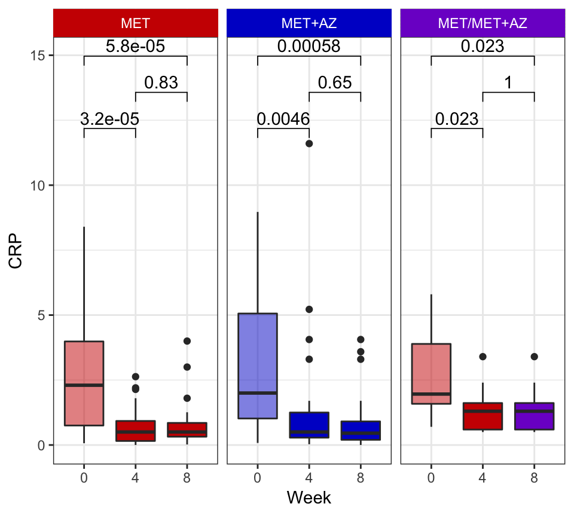

```r
df <- AZCRO_Subject_df

df <- rbind(
  data.frame(Subject_ID = df$Subject_ID,
             Treatment_Group = df$Treatment_Group,
             CRP = df$CRP_Week0,
             Week = "Week0"),
  data.frame(Subject_ID = df$Subject_ID,
             Treatment_Group = df$Treatment_Group,
             CRP = df$CRP_Week4,
             Week = "Week4"),
  data.frame(Subject_ID = df$Subject_ID,
             Treatment_Group = df$Treatment_Group,
             CRP = df$CRP_Week8,
             Week = "Week8"))
df$Group_By_Week <- paste0(df$Treatment_Group, "_", df$Week)

df$Antibiotics <- NA
df$Antibiotics[df$Week %in% c("Week0")] <-"Pre-Antibiotics"
df$Antibiotics[df$Week %in% c("Week4", "Week8")] <- "Current Antibiotics"
df$Antibiotics[df$Week %in% c("Week12") &
                        df$Treatment_Group %in% c("MET", "MET+AZ")] <- "Post-Antibiotics"
df$Antibiotics[df$Week %in% c("Week12") &
                        df$Treatment_Group %in% c("MET/MET+AZ")] <- "Antibiotics"
df$Antibiotics <- factor(df$Antibiotics, levels = c("Pre-Antibiotics", "Current Antibiotics", "Post-Antibiotics"))

df <- df[!is.na(df$CRP),]

df$Week_Number <- as.numeric(sapply(strsplit(as.character(df$Week), "k"), `[`, 2))
df$Week_Number <- factor(df$Week_Number, levels = c(0,4,8,12))

require("ggpubr")

comps <- list(c("0", "4"),
              c("4", "8"),
              c("0", "8"))

p <- ggplot(df, aes(x = Week_Number, y = CRP))
p <- p + geom_boxplot(aes(fill = Group_By_Week, alpha = Antibiotics))
p <- p + scale_fill_manual(name = "Treatment Group", values = Group_By_Week_pal)
p <- p + scale_alpha_manual(values = Antibiotics_pal)
p <- p + facet_grid(~Treatment_Group)
p <- p + xlab("Week")
p <- p + ylab("CRP")
p <- p + stat_compare_means(comparisons = comps, method = "wilcox.test")
p <- p + theme(legend.position="none")
#p

#########
# dummy plot for grobs
d <- ggplot(df, aes(x = Week_Number, y = CRP))
d <- d + geom_rect(aes(fill = Group_By_Week),xmin=-Inf, xmax=Inf, ymin=-Inf, ymax=Inf)
d <- d + scale_fill_manual(name = "Treatment Groups", values = Group_By_Week_pal)
d <- d + facet_grid("~ Treatment_Group")
d <- d + theme_minimal()
d <- d + theme(strip.text = element_text(colour = 'white'))
#d

library(gtable)
library(grid)

g1 <- ggplotGrob(p)
g2 <- ggplotGrob(d)

gtable_select <- function (x, ...)
{
  matches <- c(...)
  x$layout <- x$layout[matches, , drop = FALSE]
  x$grobs <- x$grobs[matches]
  x
}

panels <- grepl(pattern="panel", g2$layout$name)
strips <- grepl(pattern="strip-t", g2$layout$name)
g2$layout$t[panels] <- g2$layout$t[panels] - 1
g2$layout$b[panels] <- g2$layout$b[panels] - 1
new_strips <- gtable_select(g2, panels | strips)

gtable_stack <- function(g1, g2){
  g1$grobs <- c(g1$grobs, g2$grobs)
  g1$layout <- transform(g1$layout, z= z-max(z), name="g2")
  g1$layout <- rbind(g1$layout, g2$layout)
  g1
}

new_plot <- gtable_stack(g1, new_strips)
grid.newpage()
grid.draw(new_plot)
```

```r
pdf(paste0(SavePath,"plot_boxplot_Weeks0-8_CRP.pdf"), width=5,height=4.5)
  grid.draw(new_plot)
invisible(dev.off())
```

## Figure S1B. ESR

Erythrocyte Sedimentation Rate: Blood test that measures how quickly erythrocytes settle at the bottom of a test tube that contains a blood sample. Faster rates indicate inflammation.

Box plots display differences in means between the groups.

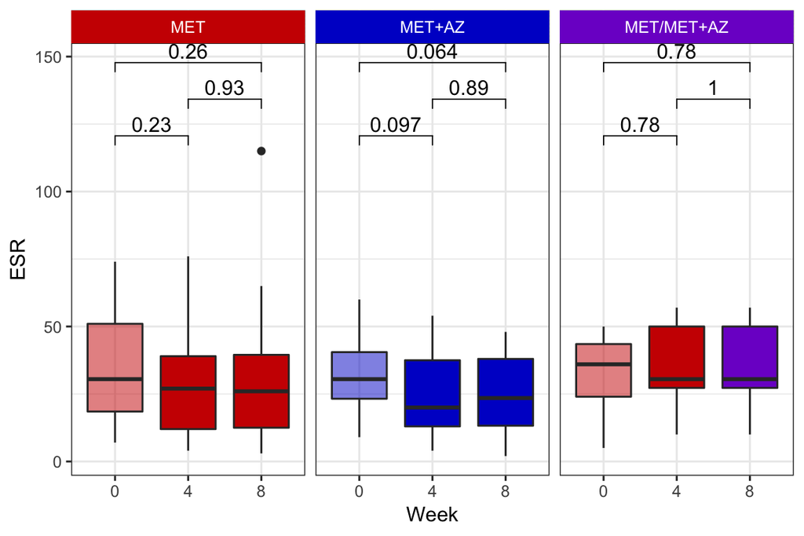

```r
df <- AZCRO_Subject_df

df <- rbind(
  data.frame(Subject_ID = df$Subject_ID,
             Treatment_Group = df$Treatment_Group,
             ESR = df$ESR_Week0,
             Week = "Week0"),
  data.frame(Subject_ID = df$Subject_ID,
             Treatment_Group = df$Treatment_Group,
             ESR = df$ESR_Week4,
             Week = "Week4"),
  data.frame(Subject_ID = df$Subject_ID,
             Treatment_Group = df$Treatment_Group,
             ESR = df$ESR_Week8,
             Week = "Week8"))
df$Group_By_Week <- paste0(df$Treatment_Group, "_", df$Week)

df$Antibiotics <- NA
df$Antibiotics[df$Week %in% c("Week0")] <-"Pre-Antibiotics"
df$Antibiotics[df$Week %in% c("Week4", "Week8")] <- "Current Antibiotics"
df$Antibiotics[df$Week %in% c("Week12") &
                        df$Treatment_Group %in% c("MET", "MET+AZ")] <- "Post-Antibiotics"
df$Antibiotics[df$Week %in% c("Week12") &
                        df$Treatment_Group %in% c("MET/MET+AZ")] <- "Antibiotics"
df$Antibiotics <- factor(df$Antibiotics, levels = c("Pre-Antibiotics", "Current Antibiotics", "Post-Antibiotics"))

df <- df[!is.na(df$ESR),]

df$Week_Number <- as.numeric(sapply(strsplit(as.character(df$Week), "k"), `[`, 2))
df$Week_Number <- factor(df$Week_Number, levels = c(0,4,8,12))

require("ggpubr")

comps <- list(c("0", "4"),
              c("4", "8"),
              c("0", "8"))

p <- ggplot(df, aes(x = Week_Number, y = ESR))
p <- p + geom_boxplot(aes(fill = Group_By_Week, alpha = Antibiotics))
p <- p + scale_fill_manual(name = "Treatment Group", values = Group_By_Week_pal)
p <- p + scale_alpha_manual(values = Antibiotics_pal)
p <- p + facet_grid(~Treatment_Group)
p <- p + xlab("Week")
p <- p + ylab("ESR")
p <- p + stat_compare_means(comparisons = comps, method = "wilcox.test")
p <- p + theme(legend.position="none")
#p

#########
# dummy plot for grobs
d <- ggplot(df, aes(x = Week_Number, y = ESR))
d <- d + geom_rect(aes(fill = Group_By_Week),xmin=-Inf, xmax=Inf, ymin=-Inf, ymax=Inf)
d <- d + scale_fill_manual(name = "Treatment Groups", values = Group_By_Week_pal)
d <- d + facet_grid("~ Treatment_Group")
d <- d + theme_minimal()
d <- d + theme(strip.text = element_text(colour = 'white'))
#d

library(gtable)
library(grid)

g1 <- ggplotGrob(p)
g2 <- ggplotGrob(d)

gtable_select <- function (x, ...)
{
  matches <- c(...)
  x$layout <- x$layout[matches, , drop = FALSE]
  x$grobs <- x$grobs[matches]
  x
}

panels <- grepl(pattern="panel", g2$layout$name)
strips <- grepl(pattern="strip-t", g2$layout$name)
g2$layout$t[panels] <- g2$layout$t[panels] - 1
g2$layout$b[panels] <- g2$layout$b[panels] - 1
new_strips <- gtable_select(g2, panels | strips)

gtable_stack <- function(g1, g2){
  g1$grobs <- c(g1$grobs, g2$grobs)
  g1$layout <- transform(g1$layout, z= z-max(z), name="g2")
  g1$layout <- rbind(g1$layout, g2$layout)
  g1
}

new_plot <- gtable_stack(g1, new_strips)
grid.newpage()
grid.draw(new_plot)
```

```r
pdf(paste0(SavePath,"plot_boxplot_Weeks0-8_ESR.pdf"), width=5,height=4.5)
  grid.draw(new_plot)
invisible(dev.off())
```

## Figure S1C. Calprotectin

Calprotectin: Elevated faecal calprotectin indicates the migration of neutrophils to the intestinal mucosa, which occurs during intestinal inflammation.

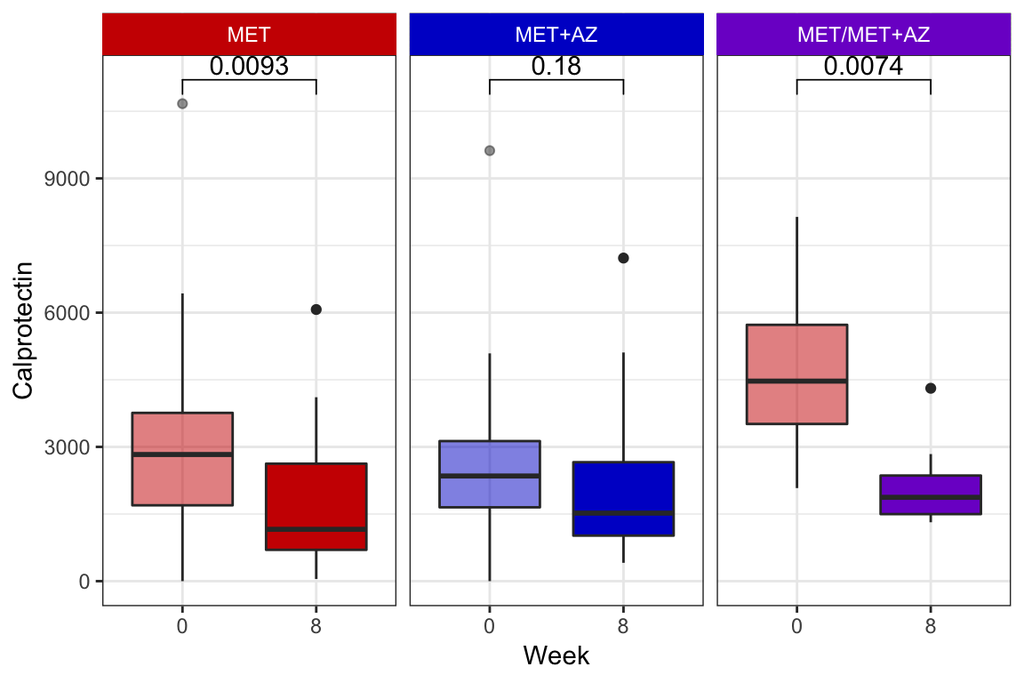

```r
df <- AZCRO_Subject_df

df <- rbind(
  data.frame(Subject_ID = df$Subject_ID,
             Treatment_Group = df$Treatment_Group,
             Calprotectin = df$Calprotectin_Week0,
             Week = "Week0"),
  data.frame(Subject_ID = df$Subject_ID,
             Treatment_Group = df$Treatment_Group,
             Calprotectin = df$Calprotectin_Week8,
             Week = "Week8"))
df$Group_By_Week <- paste0(df$Treatment_Group, "_", df$Week)

df$Antibiotics <- NA
df$Antibiotics[df$Week %in% c("Week0")] <-"Pre-Antibiotics"
df$Antibiotics[df$Week %in% c("Week4", "Week8")] <- "Current Antibiotics"
df$Antibiotics[df$Week %in% c("Week12") &
                        df$Treatment_Group %in% c("MET", "MET+AZ")] <- "Post-Antibiotics"
df$Antibiotics[df$Week %in% c("Week12") &
                        df$Treatment_Group %in% c("MET/MET+AZ")] <- "Antibiotics"
df$Antibiotics <- factor(df$Antibiotics, levels = c("Pre-Antibiotics", "Current Antibiotics", "Post-Antibiotics"))

df <- df[!is.na(df$Calprotectin),]

df$Week_Number <- as.numeric(sapply(strsplit(as.character(df$Week), "k"), `[`, 2))
df$Week_Number <- factor(df$Week_Number, levels = c(0,4,8,12))

require("ggpubr")

comps <- list(c("0", "8"))

p <- ggplot(df, aes(x = Week_Number, y = Calprotectin))
p <- p + geom_boxplot(aes(fill = Group_By_Week, alpha = Antibiotics))
p <- p + scale_fill_manual(name = "Treatment Group", values = Group_By_Week_pal)
p <- p + scale_alpha_manual(values = Antibiotics_pal)
p <- p + facet_grid(~Treatment_Group)
p <- p + xlab("Week")
p <- p + ylab("Calprotectin")
p <- p + stat_compare_means(comparisons = comps, method = "wilcox.test")
p <- p + theme(legend.position="none")
#p

#########
# dummy plot for grobs
d <- ggplot(df, aes(x = Week_Number, y = Calprotectin))
d <- d + geom_rect(aes(fill = Group_By_Week),xmin=-Inf, xmax=Inf, ymin=-Inf, ymax=Inf)
d <- d + scale_fill_manual(name = "Treatment Groups", values = Group_By_Week_pal)
d <- d + facet_grid("~ Treatment_Group")
d <- d + theme_minimal()
d <- d + theme(strip.text = element_text(colour = 'white'))
#d

library(gtable)
library(grid)

g1 <- ggplotGrob(p)
g2 <- ggplotGrob(d)

gtable_select <- function (x, ...)
{
  matches <- c(...)
  x$layout <- x$layout[matches, , drop = FALSE]
  x$grobs <- x$grobs[matches]
  x
}

panels <- grepl(pattern="panel", g2$layout$name)
strips <- grepl(pattern="strip-t", g2$layout$name)
g2$layout$t[panels] <- g2$layout$t[panels] - 1
g2$layout$b[panels] <- g2$layout$b[panels] - 1
new_strips <- gtable_select(g2, panels | strips)

gtable_stack <- function(g1, g2){
  g1$grobs <- c(g1$grobs, g2$grobs)
  g1$layout <- transform(g1$layout, z= z-max(z), name="g2")
  g1$layout <- rbind(g1$layout, g2$layout)
  g1
}

new_plot <- gtable_stack(g1, new_strips)
grid.newpage()
grid.draw(new_plot)
```

```r
pdf(paste0(SavePath,"plot_boxplot_Weeks0-8_Calprotectin.pdf"), width=5,height=4.5)
  grid.draw(new_plot)
invisible(dev.off())
```

Proceed to the second major analysis: `VA08_a7_180819.2.Rmd`